# Assessing Power of the California Microhap Baseline for PBT and relationship inference

Eric C. Anderson

Last Updated: 2025-03-27

```r
if(exists("snakemake")) {
  input_list <- snakemake@input
  output_list <- snakemake@output
  threads <- as.numeric(snakemake@threads)
} else {
  input_list <- list(
    final_baseline = "data/SWFSC-chinook-reference-baseline.csv.gz",
    pop_labels = "inputs/reference-collection-names.csv",
    locus_info = "inputs/Calif-Chinook-Amplicon-Panel-Information.csv"
  )
  output_list <- list(
    ckmr_figure_tex = "tex/images/fpr-fnr-figure-crop.pdf",
    frh_comp_tex = "tex/images/frh-comp-figure-crop.pdf"
  )
  threads <- 8
}

# add the intermediates that are not really outputs
output_list <- c(
  output_list,
  ckmr_figure = "results/ckmr-sim-eval/fpr-fnr-figure.pdf",
  ckmr_figure_crop = "results/ckmr-sim-eval/fpr-fnr-figure-crop.pdf",
  ckmr_comp = "results/ckmr-sim-eval/cmkr-comp-figure.pdf",
  ckmr_comp_crop = "results/ckmr-sim-eval/cmkr-comp-figure-crop.pdf",
  frh_comp = "results/ckmr-sim-eval/frh-comp-figure.pdf",
  frh_comp_crop = "results/ckmr-sim-eval/frh-comp-figure-crop.pdf",
  ckmr_comp_tex = "tex/images/cmkr-comp-figure-crop.pdf" # ggsave doesn't save this, so see code comments below
)

# you can create the necessary output directories like this:
dump <- lapply(output_list, function(x)
  dir.create(dirname(x), recursive = TRUE, showWarnings = FALSE)
)
```

## Wrangle the data

```r
library(tidyverse)
library(CKMRsim)
library(readxl)
library(parallel)
library(grid)
library(gridExtra)


# ensure that Mendel is installed into the CKMRsim package tree:
install_mendel(Dir = system.file(package = "CKMRsim"))
```

```
## [1] TRUE
```

```r
# get the full baseline with the new markers, etc.  We will toss out some
# non-winter Sacto fish of unknown provenance
full_base <- read_csv(input_list$final_baseline)

# read the pop labels for proper sorting
pop_labels <- read_csv(input_list$pop_labels)

# rename those collections and repunits
full_base2 <- full_base %>%
  rename(old_name = collection) %>%
  select(-repunit) %>%
  left_join(pop_labels %>% select(old_name, collection, repunit, ckmr_sim_group), by = join_by(old_name)) %>%
  select(-old_name) %>%
  select(indiv, repunit, collection, sample_type, ckmr_sim_group, everything())


# after that, we can nest things into separate ckmr_sim_groups
ckmr_sim_nests <- full_base2 %>%
  group_by(ckmr_sim_group) %>%
  nest()


# now, we also want to get the genome positions of things.
# we take its position to be the start position of the amplicon
gen_coords <- read_csv(input_list$locus_info) %>%
  rename(Locus = AmpliconName, Chrom = Otsh_v2.0_chromosome, Pos = AmpliconStartPos) %>%
  select(Locus, Chrom, Pos) %>%
  filter(!str_detect(Locus, "sexy"))
```

## Now, a series of functions to operate on each nest and do CKMRsim things

```r
#' @param X a tibble like that nested in a single row of ckmr_sim_nests
#' @param GC2 essentially the gen_coords object from above
ckmr_afreqs_ready <- function(X, GC2) {
  tmp <- X %>%
    select(-(repunit:sample_type)) %>%
    pivot_longer(
      -indiv,
      names_to = c("Locus", "gene_copy"),
      values_to = "Allele",
      names_pattern = "^(.*)_([12])$"
    ) %>%
    filter(!is.na(Allele)) %>%
    count(Locus, Allele) %>%
    group_by(Locus) %>%
    filter(n() > 1) %>% # filter out monomorphic loci
    mutate(
      Freq = n / sum(n),
    ) %>%
    ungroup() %>%
    filter(!is.na(Locus)) %>%  # this gets rid of the rosa stuff
    left_join(GC2, by = join_by(Locus)) %>%
    select(Chrom, Pos, Locus, Allele, Freq) %>%
    arrange(Pos, desc(Freq))

  no_pos_posse <- tmp %>%
    filter(is.na(Chrom))

  if(nrow(no_pos_posse) > 0) {
    warning("Some loci without genomic positions: ", paste(unique(no_pos_posse$Locus), collapse = ", "), "\n\n")
    warning("Those loci were dropped, and the analysis should survive, but you should see what's up!")
  }

  # then, return thing without the no_pos_posse markers
  tmp %>%
    filter(!is.na(Chrom)) %>%
    mutate(
      AlleIdx = NA,
      LocIdx = NA
    ) %>%
    CKMRsim::reindex_markers()

}


# here is one to create a ckmr object.
# Y is simply the output of ckmr_afreqs_ready()
ckmr_create <- function(Y) {
  create_ckmr(
    D = Y,
    kappa_matrix = kappas[c("PO", "FS", "HS", "AN", "U"), ],
    ge_mod_assumed = ge_model_TGIE,
    ge_mod_true = ge_model_TGIE,
    ge_mod_assumed_pars_list = list(epsilon = 0.005),
    ge_mod_true_pars_list = list(epsilon = 0.005)
  )
}


# This does the simulate_Qij step and then also estimates the FPRs.
ckmr_simQ <- function(C, unlinked = FALSE, num_mc_samples = 1e5) {
  simulate_Qij(
    C,
    reps = num_mc_samples,  # 100,000 monte carlo samples by default
    calc_relats = c("PO", "FS", "HS", "AN", "U"),
    sim_relats = c("PO", "FS", "HS", "AN", "U"),
    unlinked = unlinked,
    pedigree_list = pedigrees
  )
}
```

And here is a function that does the above and then spits out some FPRs and FNRs:

```r
get_FPRs_and_FNRs <- function(X, GC2 = gen_coords) {

  Y <- ckmr_afreqs_ready(X, GC2)

  C <- ckmr_create(Y)

  # throttle text output to console
  options(CKMRsim.discard_stdout = TRUE)
  options(CKMRsim.linkage_verbosity = 0)

  # Simulate some Q_ij's. Suppress output messages that the CKMRsim package
  # produces
  Q_link <- ckmr_simQ(C) #%>% suppressMessages()
  Q_unl <- ckmr_simQ(C, unlinked = TRUE) #%>% suppressMessages()

  # get FPRs and FNRs for a variety of relationships.  Return in a big tibble

  ret <- list(
    # first for resolving unrelated individuals from PO and FS (and HS, for which there is no hope!)
    all_v_unrel = mc_sample_simple(
      Q = Q_unl,
      Q_for_fnrs = Q_link,
      nu = c("PO", "FS", "HS"),
      de = "U",
      tr = "U",
      method = "IS",
      FNRs = seq(0.01, 0.3, by = 0.01)
    ),
    # then, vanilla MCMC to see how readily we can distinguish FS from PO,
    # and then, of course FS from HS and PO from A, etc.
    po_vs_fs = mc_sample_simple(
      Q = Q_link,
      nu = c("PO"),
      de = "FS",
      tr = "FS",
      method = "vanilla",
      FNRs = seq(0.01, 0.3, by = 0.01)
    ),
    fs_vs_po = mc_sample_simple(
      Q = Q_link,
      nu = c("FS"),
      de = "PO",
      tr = "PO",
      method = "vanilla",
      FNRs = seq(0.01, 0.3, by = 0.01)
    ),
    fs_vs_hs = mc_sample_simple(
      Q = Q_link,
      nu = c("FS"),
      de = "HS",
      tr = "HS",
      method = "vanilla",
      FNRs = seq(0.01, 0.3, by = 0.01)
    ),
    po_vs_hs = mc_sample_simple(
      Q = Q_link,
      nu = c("PO"),
      de = "HS",
      tr = "HS",
      method = "vanilla",
      FNRs = seq(0.01, 0.3, by = 0.01)
    ),
    po_vs_an = mc_sample_simple(
      Q = Q_link,
      nu = c("PO"),
      de = "AN",
      tr = "AN",
      method = "vanilla",
      FNRs = seq(0.01, 0.3, by = 0.01)
    )
  ) %>%
    bind_rows(.id = "what_it_was")

  ret
}
```

I tried ripping through everything using furrr::future_map() but that did not actually do it in parallel. So we are going to just mclapply it:

```r
set.seed(5)
tmp_list <- mclapply(
  X = ckmr_sim_nests$data,
  FUN = function(x) get_FPRs_and_FNRs(x),
  mc.cores = threads
)

ckmr_sim_results <- tibble(
  ckmr_sim_nests,
  fprs = tmp_list
)
```

## Make a plot with all those results

```r
# unnest it
ckmr_sim_tib <- ckmr_sim_results %>%
  select(-data) %>%
  unnest(fprs) %>%
  ungroup()

# just print out the different scenarios simulated
ckmr_sim_tib %>%
  distinct(mc_method, numerator, denominator, true_relat)
```

| mc_method | numerator | denominator | true_relat |
| --- | --- | --- | --- |
| IS | PO | U | U |
| IS | FS | U | U |
| IS | HS | U | U |
| vanilla | PO | FS | FS |
| vanilla | FS | PO | PO |
| vanilla | FS | HS | HS |
| vanilla | PO | HS | HS |
| vanilla | PO | AN | AN |

Now name the groups a little differently and sort them so that they are sorted like they are in the other figures.

```r
CST0 <- ckmr_sim_tib %>%
  mutate(
    group = str_replace(ckmr_sim_group, "^ck-", ""),
    group = case_match(
      group,
      "LF" ~ "CHLF",
      "IGH" ~ "IGHF",
      "SONC" ~ "SO-NCal-Coast",
      "CCC" ~ "Cent-Cal-Coast",
      .default = group
    ),
    .before = ckmr_sim_group
  ) %>%
  mutate(group = factor(group, levels = c("SO-NCal-Coast", "IGHF", "TRH", "Cent-Cal-Coast", "SRW", "BCS", "MDS", "FRH", "CVF", "CHLF")))
```

Now, make a figure of those results.

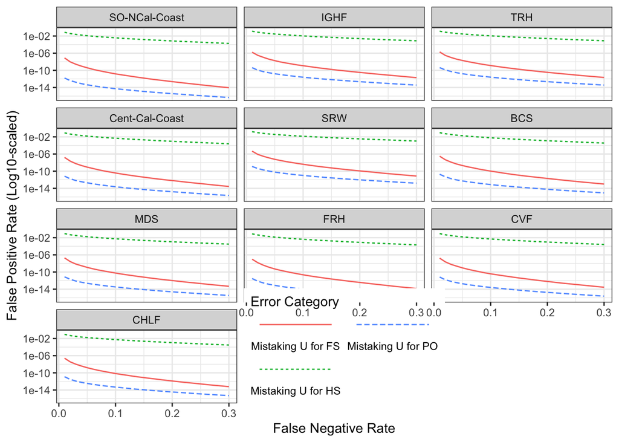

```r
# first, try a simple way of categorizing the errors
error_types_tib <- tribble(
  ~"scenario", ~"Error Category",
  "IS-FS-U-U", "Mistaking U for FS",
  "IS-HS-U-U", "Mistaking U for HS",
  "IS-PO-U-U", "Mistaking U for PO",
  "vanilla-FS-HS-HS", "Mistaking HS for FS",
  "vanilla-FS-PO-PO", "Mistaking PO for FS",
  "vanilla-PO-AN-AN", "Mistaking AN for PO",
  "vanilla-PO-FS-FS", "Mistaking FS for PO",
  "vanilla-PO-HS-HS", "Mistaking HS for PO"
)

cst2 <- CST0 %>%
  mutate(scenario = str_c(mc_method, numerator, denominator, true_relat, sep = "-")) %>%
  left_join(error_types_tib, by = join_by(scenario))



# first do the importance sampling ones
g <- ggplot(cst2 %>% filter(mc_method == "IS"), aes(x = FNR, y = FPR, colour = `Error Category`, linetype = `Error Category`)) +
  geom_line() +
  #geom_segment(aes(x = FNR, xend = FNR, y = FPR - 2 * se, yend = FPR + 2 * se)) +
  facet_wrap(~ group, nrow = 4) +
  scale_y_continuous(trans = "log10") +
  theme_bw() +
  theme(legend.direction = "horizontal") +
  xlab("False Negative Rate") +
  ylab("False Positive Rate (Log10-scaled)") +
  guides(
    colour = guide_legend(
      title.position = "top",
      label.position = "bottom",
      nrow = 2
      )
  ) +
  guides(
    linetype = guide_legend(
      title.position = "top",
      label.position = "bottom",
      nrow = 2
      )
  )

library(lemon)
a <- reposition_legend(g, panel = "panel-2-3",  x = 0, y = 0, just = c(0,0))
```

Now, let’s look at the vanilla ones:

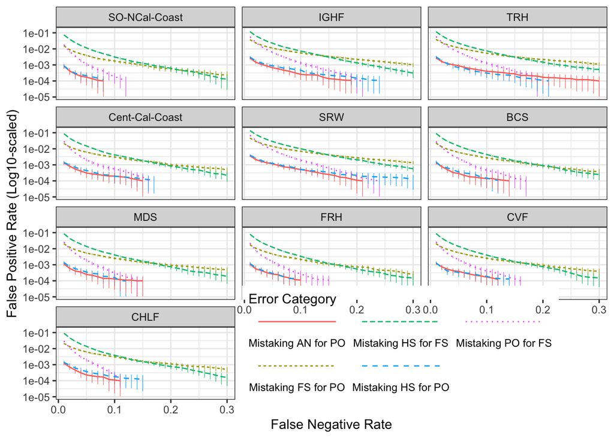

```r
g2 <- ggplot(
  cst2 %>% filter(mc_method == "vanilla" & FPR > 0 & FPR - 2 * sqrt(FPR * (1 - FPR) / 5e4) > 0.8e-05),
  aes(x = FNR, y = FPR)) +
  geom_segment(
    aes(
      x = FNR,
      xend = FNR,
      y = FPR - 2 * sqrt(FPR * (1 - FPR) / 5e4),
      yend = FPR + 2 * sqrt(FPR * (1 - FPR) / 5e4),
      colour = `Error Category`
    ),
    linewidth = 0.2,
    show.legend = FALSE
  ) +
  geom_line(aes(colour = `Error Category`, linetype = `Error Category`)) +
  facet_wrap(~ group, nrow = 4) +
  scale_y_continuous(trans = "log10") +
  theme_bw() +
  theme(legend.direction = "horizontal") +
  xlab("False Negative Rate") +
  ylab("False Positive Rate (Log10-scaled)") +
  guides(
    colour = guide_legend(
      title.position = "top",
      label.position = "bottom",
      nrow = 2),
    linetype = guide_legend(
      title.position = "top",
      label.position = "bottom",
      nrow = 2)
  ) +
  theme(legend.direction = "horizontal")

a2 <- reposition_legend(g2, panel = "panel-2-3", x = 0, y = 0, just = c(0,0))
```

Then cowplot it:

```r
Both <- cowplot::plot_grid(a, a2, nrow = 1, labels = c("a)", "b)"))

ggsave(Both, filename = output_list$ckmr_figure, width = 12, height = 7)


# let's crop that down for use, too
CALL <- paste("pdfcrop ", output_list$ckmr_figure, collapse = " ")
system(CALL)

file.rename(from = output_list$ckmr_figure_crop, to = output_list$ckmr_figure_tex)
```

```
## [1] TRUE
```

# Logl Ratio Plot Comparisons

Neil suggested, and Carlos and I agreed, that one way to see the improvement in relationship inference obtained by using multiallelic microhaps is to look at the separation of the different relationship log-likelihood ratios when using just the best (MAF closest to 0.5) SNP from each locus, or when using all the SNPs/alleles. We deciced to do this for the hatchery populations in California, as well as the winter run. I am going to implement this in a few functions, each of which operate on the one of the ckmr_sim_nests.

```r
#' function to get just the best SNP out of each microhap
#'
#' This works on a single collection at a time.
#' @param X a tibble like that nested in a single row of ckmr_sim_nests
#' @return Returns a tibble like X, but with just the best SNP from
#' each amplicon (note that it might also drop some monomorphic amplicons).
retain_top_snp <- function(X) {
  # first, get the microhaps in long format
  tmp <- X %>%
    select(-(repunit:sample_type)) %>%
    pivot_longer(
      -indiv,
      names_to = c("Locus", "gene_copy"),
      values_to = "Allele",
      names_pattern = "^(.*)_([12])$"
    ) %>%
    filter(!is.na(Allele))

  # then explode it out to individual SNPs
  exploded <- tmp %>%
    mutate(
      snp_num = map(Allele, function(x) 1:nchar(x)),
      snp_alle = map(Allele, function(x) strsplit(x, "")[[1]])
    ) %>%
    unnest(cols = c(snp_num, snp_alle))

  # now, get the highest maf snp at each locus in a tibble
  highest_mafs <- exploded %>%
    count(Locus, snp_num, snp_alle) %>%
    group_by(Locus, snp_num) %>%
    mutate(af = n / sum(n)) %>%
    filter(af <= 0.5) %>%
    ungroup() %>%
    arrange(Locus, desc(af)) %>%
    group_by(Locus) %>%
    slice(1) %>%
    ungroup()

  # then pull those out of the "exploded" variable with a semi_join
  # and put them back into wide format, left join it onto the meta
  # data
  ret <- exploded %>%
    semi_join(highest_mafs, by = join_by(Locus, snp_num)) %>%
    select(indiv, Locus, gene_copy, snp_alle) %>%
    pivot_wider(
      names_from = c(Locus, gene_copy),
      values_from = snp_alle,
      names_sep = "_"
    ) %>%
    left_join(
      X %>% select(indiv, repunit, collection, sample_type),
      .,
      by = join_by(indiv)
    )

  ret

}
```

So, that is how we pick out the top SNP. But now we also need a function that is going to give us the set of all the simulated logl-ratios that we need (whether it is all the microhap alleles or just the top SNPs). We can build off of what we did in a function above.

```r
get_logl_rats <- function(X, GC2 = gen_coords) {

  Y <- ckmr_afreqs_ready(X, GC2)

  C <- ckmr_create(Y)

  # throttle text output to console
  options(CKMRsim.discard_stdout = TRUE)
  options(CKMRsim.linkage_verbosity = 0)

  # Simulate some Q_ij's. Suppress output messages that the CKMRsim package
  # produces
  Q_link <- ckmr_simQ(C) #%>% suppressMessages()

  # now extract the logl_ratios
  extract_logls(Q_link, numer = c(PO = 1), denom = c(U = 1))
}
```

And, with those two functions, it would appear that we have eveything we need to get the simulation results we will want. Once again we will mclapply over the populations.

```r
# collections / groups we want to do.  I originally did many, but
# just whittled it down to include in main text following a reviewer request.
pops <- c("ck-FRH", "ck-IGH", "ck-SRW", "ck-TRH")

# let's put the microhaps and the best SNPs together in a long format.
input_tibbles <- bind_rows(
  ckmr_sim_nests %>%
    filter(ckmr_sim_group %in% pops) %>%
    mutate(condition = "microhaps", .before = ckmr_sim_group),
  ckmr_sim_nests %>%
    filter(ckmr_sim_group %in% pops) %>%
    mutate(tops = map(data, retain_top_snp)) %>%
    mutate(data = tops) %>%
    select(-tops) %>%
    mutate(condition = "top_snps", .before = ckmr_sim_group)
)

Qsims <- mclapply(input_tibbles$data, get_logl_rats, mc.cores = threads)

AllSims <- tibble(
  condition = input_tibbles$condition,
  ckmr_sim_group = input_tibbles$ckmr_sim_group,
  Qsims = Qsims
) %>%
  unnest(Qsims) %>%
  select(condition, ckmr_sim_group, true_relat, logl_ratio) %>%
  mutate(  # change the names around
    group = str_replace(ckmr_sim_group, "^ck-", ""),
    group = case_match(
      group,
      "LF" ~ "CHLF",
      "IGH" ~ "IGHF",
      "SONC" ~ "SO-NCal-Coast",
      "CCC" ~ "Cent-Cal-Coast",
      .default = group
    ),
    .before = ckmr_sim_group
  ) %>%
  mutate(group = factor(group, levels = c("SO-NCal-Coast", "IGHF", "TRH", "Cent-Cal-Coast", "SRW", "BCS", "MDS", "FRH", "CVF", "CHLF")))
```

Now, we can plot all of those. Let’s see if we can get all four onto one page easily enough.

[figure not shown]

```r
asg <- ggplot(AllSims, aes(x = logl_ratio, fill = true_relat)) +
  geom_density(alpha = 0.5) +
  facet_wrap(~ group + condition, ncol = 1) +
  theme_bw() +
  labs(fill = "True\nRelationship") +
  xlab("PO vs U Log-likelihood Ratio")

# this fails for some reason (ggsave never returns)
# ggsave(asg, path = "boing.png", height = 15, width = 9)

# So, instead I just print the thing in the Rstudio window and export it
# at size 13" high by 10" wide. Then I moved it to where it belongs in the tex directory.
# at tex/images/cmkr-comp-figure-crop.pdf
asg
```

## Making a comparison figure for the main text

```r
pop <- c("ck-FRH")

# let's put the microhaps and the best SNPs together in a long format.
input_tibbles2 <- bind_rows(
  ckmr_sim_nests %>%
    filter(ckmr_sim_group %in% pop) %>%
    mutate(condition = "microhaps", .before = ckmr_sim_group),
  ckmr_sim_nests %>%
    filter(ckmr_sim_group %in% pop) %>%
    mutate(tops = map(data, retain_top_snp)) %>%
    mutate(data = tops) %>%
    select(-tops) %>%
    mutate(condition = "top_snps", .before = ckmr_sim_group)
)


# a new function that gets multiple logls out of it
get_logl_rats_multi <- function(X, GC2 = gen_coords) {

  Y <- ckmr_afreqs_ready(X, GC2)

  C <- ckmr_create(Y)

  # throttle text output to console
  options(CKMRsim.discard_stdout = TRUE)
  options(CKMRsim.linkage_verbosity = 0)

  # Simulate some Q_ij's. Suppress output messages that the CKMRsim package
  # produces
  Q_link <- ckmr_simQ(C) #%>% suppressMessages()

  # now extract the logl_ratios for PO, FS, or HS vs U and return those
  list(
    POU = extract_logls(Q_link, numer = c(PO = 1), denom = c(U = 1)),
    FSU = extract_logls(Q_link, numer = c(FS = 1), denom = c(U = 1)),
    HSU = extract_logls(Q_link, numer = c(HS = 1), denom = c(U = 1))
  ) %>%
    bind_rows(.id = "ratio_type")
}



Qsims2 <- lapply(input_tibbles2$data, get_logl_rats_multi)

AllSims2 <- tibble(
  condition = input_tibbles2$condition,
  ckmr_sim_group = input_tibbles2$ckmr_sim_group,
  Qsims = Qsims2
) %>%
  unnest(Qsims) %>%
  filter(  # only keep the relevant ones
    (ratio_type == "POU" & true_relat %in% c("U", "PO")) |
      (ratio_type == "FSU" & true_relat %in% c("U", "FS")) |
      (ratio_type == "HSU" & true_relat %in% c("U", "HS"))
  )
```

Now, we make a picture of that.

```r
library(ggpattern)
AS3 <- AllSims2 %>%
  mutate(
    ratio_type = case_match(
      ratio_type,
      "POU" ~ "Parent-offspring versus Unrelated log-likelihood ratio",
      "FSU" ~ "Full-sibling versus Unrelated log-likelihood ratio",
      "HSU" ~ "Half-sibling versus Unrelated log-likelihood ratio"
    ),
    ratio_type = factor(
      ratio_type,
      levels = c(
        "Parent-offspring versus Unrelated log-likelihood ratio",
        "Full-sibling versus Unrelated log-likelihood ratio",
        "Half-sibling versus Unrelated log-likelihood ratio"
      )
    )
  ) %>%
  rename(`True\nRelationship` = true_relat)

g8 <- ggplot(AS3, aes(x = logl_ratio, fill = `True\nRelationship`, alpha = condition)) +
  geom_density() +
  scale_alpha_manual(values = c(microhaps = 0.7, top_snps = 0.3)) +
  facet_wrap(~ratio_type, ncol = 1, scales = "free") +
  xlab("Log-likelihood Ratio") +
  ylab("Density") +
  theme_bw() +
  theme(legend.position = "top") +
  guides(alpha = "none")


ggsave(g8, filename = output_list$frh_comp, width = 4, height = 6)

# let's crop that down for use, too
CALL <- paste("pdfcrop ", output_list$frh_comp, collapse = " ")
system(CALL)

file.rename(from = output_list$frh_comp_crop, to = output_list$frh_comp_tex)
```

```
## [1] TRUE
```

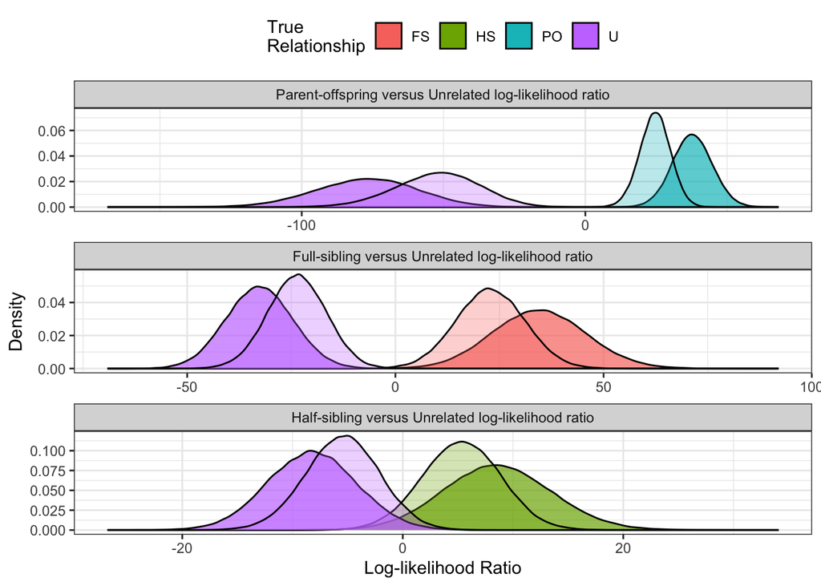

```r
g8
```

# Running Time

Running the code and rendering this notebook required approximately this much time:

```r
Sys.time() - start_time
```

```
## Time difference of 9.146791 mins
```